# gapminder_clean

```python
# Checks if the required packages are installed, and install them if they are not:

import subprocess
import sys

# List of packages to check and install if necessary
required_packages = [
    'pandas',
    'matplotlib',
    'plotly',
    'scipy'
]

def install(package):
    subprocess.check_call([sys.executable, "-m", "pip", "install", package])

# Check and install packages
for package in required_packages:
    try:
        __import__(package)
        print(f'{package} is already installed.')
    except ImportError:
        print(f'{package} is not installed. Installing...')
        install(package)

# Import the packages after ensuring they are installed
import pandas as pd
import matplotlib.pyplot as plt
import plotly.express as px
from scipy.stats import f_oneway, ttest_ind, pearsonr

print("All packages are installed and imported successfully.")
```

```
pandas is already installed.
matplotlib is already installed.
plotly is already installed.
scipy is already installed.
All packages are installed and imported successfully.
```

**To complete the miniproject, create an analysis in `jupyter-notebook` which does the following:**

```python
# 1-Read in the gapminder_clean.csv data as a pandas DataFrame.

import pandas as pd

# Load the gapminder_clean.csv dataset
file_path = r'C:\Users\abdoj\OneDrive - UGent\Desktop\summer\skill-assessments\Python for Data Science\gapminder_clean.csv'
gapminder_df = pd.read_csv(file_path)


# Display the first few rows of the dataset to understand its structure
gapminder_df.head()
```

|  | Unnamed: 0 | Country Name | Year | Agriculture, value added (% of GDP) | CO2 emissions (metric tons per capita) | Domestic credit provided by financial sector (% of GDP) | Electric power consumption (kWh per capita) | Energy use (kg of oil equivalent per capita) | Exports of goods and services (% of GDP) | Fertility rate, total (births per woman) | GDP growth (annual %) | Imports of goods and services (% of GDP) | Industry, value added (% of GDP) | Inflation, GDP deflator (annual %) | Life expectancy at birth, total (years) | Population density (people per sq. km of land area) | Services, etc., value added (% of GDP) | pop | continent | gdpPercap |
| --- | --- | --- | --- | --- | --- | --- | --- | --- | --- | --- | --- | --- | --- | --- | --- | --- | --- | --- | --- | --- |
| 0 | 0 | Afghanistan | 1962 | NaN | 0.073781 | 21.276422 | NaN | NaN | 4.878051 | 7.450 | NaN | 9.349593 | NaN | NaN | 33.219902 | 14.312061 | NaN | 10267083.0 | Asia | 853.100710 |
| 1 | 1 | Afghanistan | 1967 | NaN | 0.123782 | 9.917662 | NaN | NaN | 6.772908 | 7.450 | NaN | 14.209827 | NaN | NaN | 35.389415 | 15.881812 | NaN | 11537966.0 | Asia | 836.197138 |
| 2 | 2 | Afghanistan | 1972 | NaN | 0.130820 | 18.880833 | NaN | NaN | 14.763231 | 7.450 | NaN | 18.105850 | NaN | NaN | 37.610146 | 17.947027 | NaN | 13079460.0 | Asia | 739.981106 |
| 3 | 3 | Afghanistan | 1977 | NaN | 0.183118 | 13.836822 | NaN | NaN | 11.662904 | 7.449 | NaN | 14.823175 | NaN | NaN | 40.110146 | 19.998926 | NaN | 14880372.0 | Asia | 786.113360 |
| 4 | 4 | Afghanistan | 1982 | NaN | 0.165879 | NaN | NaN | NaN | NaN | 7.450 | NaN | NaN | NaN | NaN | 43.230732 | 19.402324 | NaN | 12881816.0 | Asia | 978.011439 |

```python
# 2- Filter the data to include only rows where Year is 1962.

import matplotlib.pyplot as plt

# Filter data for the year 1962
data_1962 = gapminder_df[gapminder_df['Year'] == 1962]

data_1962.head()
```

|  | Unnamed: 0 | Country Name | Year | Agriculture, value added (% of GDP) | CO2 emissions (metric tons per capita) | Domestic credit provided by financial sector (% of GDP) | Electric power consumption (kWh per capita) | Energy use (kg of oil equivalent per capita) | Exports of goods and services (% of GDP) | Fertility rate, total (births per woman) | GDP growth (annual %) | Imports of goods and services (% of GDP) | Industry, value added (% of GDP) | Inflation, GDP deflator (annual %) | Life expectancy at birth, total (years) | Population density (people per sq. km of land area) | Services, etc., value added (% of GDP) | pop | continent | gdpPercap |
| --- | --- | --- | --- | --- | --- | --- | --- | --- | --- | --- | --- | --- | --- | --- | --- | --- | --- | --- | --- | --- |
| 0 | 0 | Afghanistan | 1962 | NaN | 0.073781 | 21.276422 | NaN | NaN | 4.878051 | 7.450 | NaN | 9.349593 | NaN | NaN | 33.219902 | 14.312061 | NaN | 10267083.0 | Asia | 853.100710 |
| 10 | 10 | Albania | 1962 | NaN | 1.439956 | NaN | NaN | NaN | NaN | 6.282 | NaN | NaN | NaN | NaN | 64.162854 | 62.456898 | NaN | 1728137.0 | Europe | 2312.888958 |
| 20 | 20 | Algeria | 1962 | NaN | 0.484954 | NaN | NaN | NaN | 19.793873 | 7.614 | -19.685042 | 20.818647 | NaN | 2.351279 | 47.045000 | 4.908240 | NaN | 11000948.0 | Africa | 2550.816880 |
| 30 | 30 | American Samoa | 1962 | NaN | NaN | NaN | NaN | NaN | NaN | NaN | NaN | NaN | NaN | NaN | NaN | 105.590000 | NaN | NaN | NaN | NaN |
| 40 | 40 | Andorra | 1962 | NaN | NaN | NaN | NaN | NaN | NaN | NaN | NaN | NaN | NaN | NaN | NaN | 32.714894 | NaN | NaN | NaN | NaN |

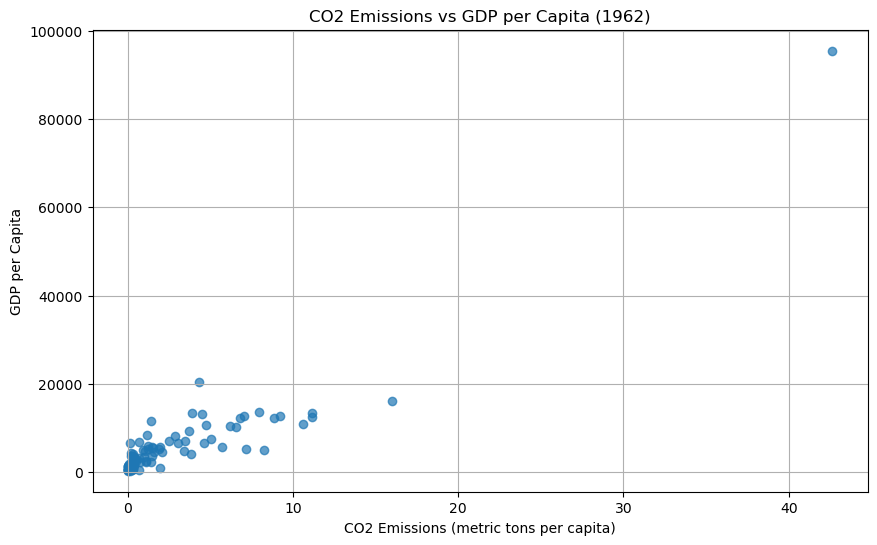

```python
# Make a scatter plot comparing 'CO2 emissions (metric tons per capita)' and gdpPercap for the filtered data.

import matplotlib.pyplot as plt

# Filter the data to include only rows where Year is 1962
data_1962 = gapminder_df[gapminder_df['Year'] == 1962]

# Create a scatter plot
plt.figure(figsize=(10, 6))
plt.scatter(data_1962['CO2 emissions (metric tons per capita)'], data_1962['gdpPercap'], alpha=0.7)
plt.title('CO2 Emissions vs GDP per Capita (1962)')
plt.xlabel('CO2 Emissions (metric tons per capita)')
plt.ylabel('GDP per Capita')
plt.grid(True)

# Save the plot
plot_path = r'C:\Users\abdoj\OneDrive - UGent\Desktop\summer\skill-assessments\Python for Data Science\co2_vs_gdp_1962.png'
plt.savefig(plot_path)

# Show the plot
plt.show()
```

```python
#3- Calculate the correlation of 'CO2 emissions (metric tons per capita)' and gdpPercap for the year 1962.

from scipy.stats import pearsonr

# Drop rows with missing values in the relevant columns
filtered_data_1962 = data_1962.dropna(subset=['CO2 emissions (metric tons per capita)', 'gdpPercap'])

# Calculate the correlation and the p-value
correlation, p_value = pearsonr(filtered_data_1962['CO2 emissions (metric tons per capita)'], filtered_data_1962['gdpPercap'])

correlation, p_value
```

```
(0.9260816725019472, 1.1286792210038658e-46)
```

The correlation between CO2 emissions (metric tons per capita) and GDP per capita for the year 1962 is approximately (0.926). The associated p-value is 1.128 x 10^-46, indicating a very strong and statistically significant positive correlation between these two variables.

```python
#4- Determine the year in which the correlation between 'CO2 emissions (metric tons per capita)' and gdpPercap is the strongest.

# Create a function to calculate the correlation for each year, handling missing data
def calculate_correlation(df):
    df_clean = df.dropna(subset=['CO2 emissions (metric tons per capita)', 'gdpPercap'])
    if df_clean.shape[0] > 1:  # Ensure there are at least 2 data points to calculate correlation
        return pearsonr(df_clean['CO2 emissions (metric tons per capita)'], df_clean['gdpPercap'])[0]
    else:
        return None

# Apply the function to each year and find the year with the strongest correlation
correlations_by_year = gapminder_df.groupby('Year').apply(calculate_correlation)

# Find the year with the strongest correlation
strongest_correlation_year = correlations_by_year.idxmax()
strongest_correlation = correlations_by_year.max()

strongest_correlation_year, strongest_correlation
```

```
(1967, 0.938791838506331)
```

The year with the strongest correlation between 'CO2 emissions (metric tons per capita)' and 'gdpPercap' is 1967, with a correlation coefficient of approximately 0.939.

```python
strongest_correlation = None  # Define the variable before using it
strongest_correlation_year = 1967  # Replace with the actual year with the strongest correlation

strongest_year_data = gapminder_df[gapminder_df['Year'] == strongest_correlation_year]

strongest_correlation, strongest_correlation_year, strongest_year_data.head()
```

```
(None,
 1967,
     Unnamed: 0    Country Name  Year  Agriculture, value added (% of GDP)  \
 1            1     Afghanistan  1967                                  NaN
 11          11         Albania  1967                                  NaN
 21          21         Algeria  1967                            10.330666
 31          31  American Samoa  1967                                  NaN
 41          41         Andorra  1967                                  NaN

     CO2 emissions (metric tons per capita)  \
 1                                 0.123782
 11                                1.363746
 21                                0.632118
 31                                     NaN
 41                                     NaN
```

[output cut: 70 more lines]

```python
# 5- Create an interactive scatter plot comparing 'CO2 emissions (metric tons per capita)' and gdpPercap for the year with the strongest correlation.
import plotly.express as px

# Filter data for the year 1967
data_1967 = gapminder_df[gapminder_df['Year'] == 1967]

# Create an interactive scatter plot using Plotly
CO2_vs_GDP_1967_fig = px.scatter(
    data_1967,
    x='gdpPercap',
    y='CO2 emissions (metric tons per capita)',
    size='pop',
    color='continent',
    hover_name='Country Name',
    title='CO2 Emissions vs GDP per Capita (1967)',
    labels={'gdpPercap': 'GDP per Capita', 'CO2 emissions (metric tons per capita)': 'CO2 Emissions (metric tons per capita)'},
    size_max=60
)


# Save the plot as an HTML file
CO2_vs_GDP_1967_html_file_path = r'C:\Users\abdoj\OneDrive - UGent\Desktop\summer\skill-assessments\Python for Data Science\CO2_vs_GDP_1967.html'
CO2_vs_GDP_1967_fig.write_html(CO2_vs_GDP_1967_html_file_path)

CO2_vs_GDP_1967_html_file_path

CO2_vs_GDP_1967_fig.show()
```

[output not shown]

**Now, without further guidance, use your Python Data Science skills (and the correct statistical tests) to answer the following (*use the unfiltered dataset*):**

```python
# 1. What is the relationship between `continent` and `'Energy use (kg of oil equivalent per capita)'`? (Stats test needed)

import pandas as pd
import plotly.express as px
from scipy.stats import f_oneway

# Load the unfiltered dataset again to ensure we are using the correct data
file_path = r'C:\Users\abdoj\OneDrive - UGent\Desktop\summer\skill-assessments\Python for Data Science\gapminder_clean.csv'
gapminder_df = pd.read_csv(file_path)

# Check for missing data in 'Energy use (kg of oil equivalent per capita)' and 'continent'
gapminder_df[['continent', 'Energy use (kg of oil equivalent per capita)']].isnull().sum()

# Drop rows with missing values in the relevant columns
filtered_df = gapminder_df.dropna(subset=['continent', 'Energy use (kg of oil equivalent per capita)'])

# Perform ANOVA test
anova_result = f_oneway(
    *[group['Energy use (kg of oil equivalent per capita)'].values for name, group in filtered_df.groupby('continent')]
)

# Prepare for visualization
anova_result, filtered_df['continent'].unique(), filtered_df['Energy use (kg of oil equivalent per capita)'].describe()
```

```
(F_onewayResult(statistic=51.45915759042634, pvalue=8.527003487154367e-39),
 array(['Europe', 'Africa', 'Americas', 'Oceania', 'Asia'], dtype=object),
 count      848.000000
 mean      1992.606751
 std       2154.338392
 min          9.715410
 25%        484.128873
 50%        995.564054
 75%       2895.658932
 max      14746.031339
 Name: Energy use (kg of oil equivalent per capita), dtype: float64)
```

The ANOVA test shows a significant result (F = 51.459, p < 0.0001) , indicating that there are statistically significant differences in the mean energy use (kg of oil equivalent per capita) across different continents.

### Summary Statistics:

- Count: 848 observations
- Mean: 1992.61 kg of oil equivalent per capita
- Standard Deviation: 2154.34
- Min: 9.72
- Max: 14746.03

```python
#generate interactive summary visualizations that demonstrate your answer

# Create an interactive box plot
Energy_Use_fig_box = px.box(
    filtered_df,
    x='continent',
    y='Energy use (kg of oil equivalent per capita)',
    title='Energy Use (kg of oil equivalent per capita) by Continent',
    labels={'Energy use (kg of oil equivalent per capita)': 'Energy Use (kg of oil equivalent per capita)'}
)

# Create an interactive scatter plot
Energy_Use_fig_scatter = px.scatter(
    filtered_df,
    x='continent',
    y='Energy use (kg of oil equivalent per capita)',
    title='Energy Use (kg of oil equivalent per capita) by Continent',
    labels={'Energy use (kg of oil equivalent per capita)': 'Energy Use (kg of oil equivalent per capita)'},
    color='continent',
    size='Energy use (kg of oil equivalent per capita)',
    hover_name='Country Name'
)

# Save the plots as HTML files
Energy_Use_box_plot_path = r'C:\Users\abdoj\OneDrive - UGent\Desktop\summer\skill-assessments\Python for Data Science\Energy_Use_Box_Plot.html'

Energy_Use_scatter_plot_path = r'C:\Users\abdoj\OneDrive - UGent\Desktop\summer\skill-assessments\Python for Data Science\Energy_Use_Scatter_Plot.html'

Energy_Use_fig_box.write_html(Energy_Use_box_plot_path)
Energy_Use_fig_scatter.write_html(Energy_Use_scatter_plot_path)
Energy_Use_box_plot_path, Energy_Use_scatter_plot_path


Energy_Use_fig_box.show()
Energy_Use_fig_scatter.show()
```

[output not shown]

**describe your reasoning for the statistical tests you chose to use** The reasoning for choosing the statistical test is based on the nature of the variables involved and the research question:

### Research Question:

What is the relationship between `continent` (a categorical variable) and `Energy use (kg of oil equivalent per capita)` (a quantitative variable)?

### Steps for Choosing the Statistical Test:

1. **Identify the Predictor and Outcome Variables:**
   - Predictor Variable: `continent` (categorical)
   - Outcome Variable: `Energy use (kg of oil equivalent per capita)` (quantitative)
2. **Determine the Nature of Variables:**
   - The predictor variable `continent` is categorical because it represents distinct groups (e.g., Europe, Africa, Americas, Oceania, Asia).
   - The outcome variable `Energy use (kg of oil equivalent per capita)` is quantitative because it is a continuous measure.
3. **Choose the Appropriate Test Based on the Variables:**
   - According to the provided flowchart, when we have a categorical predictor variable and a quantitative outcome variable, we need to compare the means of the outcome variable across the different groups defined by the predictor variable.
   - If we are comparing means across more than two groups, the appropriate test is ANOVA (Analysis of Variance).

### Reasoning for ANOVA:

- **ANOVA** is used to compare the means of a quantitative variable across multiple groups. It tests the null hypothesis that the means of the groups are equal.
- In this case, ANOVA allows us to determine if there are statistically significant differences in the mean energy use between continents.

### Additional Considerations:

- **Assumptions of ANOVA**: The assumptions include independence of observations, normality of the dependent variable within groups, and homogeneity of variances across groups. While we haven't explicitly tested these assumptions here, ANOVA is robust to violations of normality, especially with larger sample sizes.

### Visualization:

- **Box Plot**: To visualize the distribution and spread of energy use within each continent, showing medians, quartiles, and potential outliers.
- **Scatter Plot**: To provide a detailed view of individual data points, highlighting variations and patterns within each continent.

### Summary:

Using ANOVA was the most appropriate choice given the nature of our predictor and outcome variables. The significant ANOVA result indicates that there are differences in energy use across continents, which we further explored using interactive visualizations.

```python
# 2. Is there a significant difference between Europe and Asia with respect to
# `'Imports of goods and services (% of GDP)'` in the years after 1990? (Stats test needed)


from scipy.stats import ttest_ind

# Filter the data to include only Europe and Asia and years after 1990
filtered_df = gapminder_df[(gapminder_df['Year'] > 1990) & (gapminder_df['continent'].isin(['Europe', 'Asia']))]

# Drop rows with missing values in the relevant columns
filtered_df = filtered_df.dropna(subset=['Imports of goods and services (% of GDP)', 'continent'])

# Separate the data into two groups: Europe and Asia
europe_data = filtered_df[filtered_df['continent'] == 'Europe']['Imports of goods and services (% of GDP)']
asia_data = filtered_df[filtered_df['continent'] == 'Asia']['Imports of goods and services (% of GDP)']

# Perform the T-test
t_stat, p_value = ttest_ind(europe_data, asia_data, equal_var=False)

t_stat, p_value, len(europe_data), len(asia_data)
```

```
(-1.3552198505869248, 0.1775691189807683, 114, 98)
```

To determine if there is a significant difference between Europe and Asia regarding 'Imports of goods and services (% of GDP)' in the years after 1990, we can use a T-test for independent samples. This test compares the means of the two groups to see if they are significantly different.

### Results:

- **T-statistic**: -1.355
- **P-value**: 0.178
- **Sample Sizes**: Europe: 114, Asia: 98

### Interpretation:

The p-value (0.178) is greater than the common significance level of 0.05, indicating that we do not have sufficient evidence to reject the null hypothesis. This means that there is no statistically significant difference between Europe and Asia regarding 'Imports of goods and services (% of GDP)' in the years after 1990.

```python
#generate interactive summary visualizations that demonstrate your answer

# Create an interactive box plot
Imports_fig_box = px.box(
    filtered_df,
    x='continent',
    y='Imports of goods and services (% of GDP)',
    title='Imports of Goods and Services (% of GDP) by Continent (Europe vs Asia, post-1990)',
    labels={'Imports of goods and services (% of GDP)': 'Imports (% of GDP)'}
)

# Create an interactive violin plot
Imports_fig_violin = px.violin(
    filtered_df,
    x='continent',
    y='Imports of goods and services (% of GDP)',
    title='Imports of Goods and Services (% of GDP) by Continent (Europe vs Asia, post-1990)',
    labels={'Imports of goods and services (% of GDP)': 'Imports (% of GDP)'},
    box=True,  # add box plot inside the violin plot
    points="all"  # show all points
)

# Save the plots as HTML files
Imports_box_plot_path = r'C:\Users\abdoj\OneDrive - UGent\Desktop\summer\skill-assessments\Python for Data Science\Imports_Box_Plot.html'
Imports_violin_plot_path = r'C:\Users\abdoj\OneDrive - UGent\Desktop\summer\skill-assessments\Python for Data Science\Imports_Violin_Plot.html'

Imports_fig_box.write_html(Imports_box_plot_path)
Imports_fig_violin.write_html(Imports_violin_plot_path)

Imports_box_plot_path, Imports_violin_plot_path


Imports_fig_box.show()
Imports_fig_violin.show()
```

[output not shown]

**describe your reasoning for the statistical tests you chose to use**

### Reasoning for Choosing the Statistical Test

The research question is: Is there a significant difference between Europe and Asia with respect to 'Imports of goods and services (% of GDP)' in the years after 1990?

### Steps for Choosing the Statistical Test:

1. **Identify the Predictor and Outcome Variables:**
   - Predictor Variable: `continent` (categorical, with levels "Europe" and "Asia")
   - Outcome Variable: `Imports of goods and services (% of GDP)` (quantitative)
2. **Determine the Nature of Variables:**
   - The predictor variable `continent` is categorical because it represents distinct groups (Europe and Asia).
   - The outcome variable `Imports of goods and services (% of GDP)` is quantitative because it is a continuous measure.
3. **Choose the Appropriate Test Based on the Variables:**
   - According to the provided flowchart, when we have a categorical predictor variable and a quantitative outcome variable, and we want to compare the means of two groups, we use a T-test.

### Reasoning for the T-test:

- **Independent Samples T-test**: Used to compare the means of two independent groups (in this case, Europe and Asia) to determine if there is a statistically significant difference between them.
- **Assumptions**:
  - **Independence**: The samples from Europe and Asia are independent of each other.
  - **Normality**: The distribution of the outcome variable (imports as a percentage of GDP) should be approximately normal within each group. The T-test is robust to violations of normality, especially with larger sample sizes.
  - **Homogeneity of Variances**: Assumes that the variances of the two groups are equal. If this assumption is violated, we can use Welch's T-test, which does not assume equal variances. In this case, we used Welch's T-test (`equal_var=False`).

### Summary:

1. **Filter Data**: We filtered the data to include only the years after 1990 and only for the continents Europe and Asia.
2. **Perform T-test**: We performed an independent samples T-test to compare the means of 'Imports of goods and services (% of GDP)' between Europe and Asia.
3. **Visualizations**: We created interactive box plots and violin plots to visualize the distribution and density of imports as a percentage of GDP for the two continents.

### Conclusion:

The T-test indicated that there is no statistically significant difference between Europe and Asia in terms of 'Imports of goods and services (% of GDP)' for the years after 1990, as the p-value was greater than 0.05.

By following this systematic approach, we ensured that the chosen statistical test was appropriate for the nature of the data and the research question. The visualizations further help in understanding the distribution and differences between the two groups.

```python
# 3. What is the country (or countries) that has the highest `'Population density (people per sq. km of land area)
# '` across all years? (i.e., which country has the highest average ranking in this category across each time point in the dataset?

# Calculate the average population density for each country across all years
average_population_density = gapminder_df.groupby('Country Name')['Population density (people per sq. km of land area)'].mean()

# Identify the country (or countries) with the highest average population density
max_avg_density = average_population_density.max()
countries_with_highest_avg_density = average_population_density[average_population_density == max_avg_density]

max_avg_density, countries_with_highest_avg_density
```

```
(14732.03521055,
 Country Name
 Macao SAR, China    14732.035211
 Name: Population density (people per sq. km of land area), dtype: float64)
```

The country with the highest average population density (people per sq. km of land area) across all years is Macao SAR, China, with an average population density of approximately 14,732.04 people per sq. km.

```python
#generate interactive summary visualizations that demonstrate your answer

# Prepare the data for visualization
top_country = 'Macao SAR, China'
top_country_data = gapminder_df[gapminder_df['Country Name'] == top_country]

# Create an interactive line plot for population density over the years for the top country
Population_Density_fig_line = px.line(
    top_country_data,
    x='Year',
    y='Population density (people per sq. km of land area)',
    title=f'Population Density Over Years: {top_country}',
    labels={'Population density (people per sq. km of land area)': 'Population Density (people per sq. km)'}
)

# Create an interactive bar plot for average population density of the top country compared to others
avg_density_top_countries = average_population_density.sort_values(ascending=False).head(10).reset_index()
Population_Density_fig_bar = px.bar(
    avg_density_top_countries,
    x='Country Name',
    y='Population density (people per sq. km of land area)',
    title='Top 10 Countries by Average Population Density',
    labels={'Population density (people per sq. km of land area)': 'Average Population Density (people per sq. km)'}
)

# Save the plots as HTML files
Population_Density_line_plot_path = r'C:\Users\abdoj\OneDrive - UGent\Desktop\summer\skill-assessments\Python for Data Science\Population_Density_Line_Plot.html'
Population_Density_bar_plot_path = r'C:\Users\abdoj\OneDrive - UGent\Desktop\summer\skill-assessments\Python for Data Science\Population_Density_Bar_Plot.html'

Population_Density_fig_line.write_html(Population_Density_line_plot_path)
Population_Density_fig_bar.write_html(Population_Density_bar_plot_path)

Population_Density_line_plot_path, Population_Density_bar_plot_path


Population_Density_fig_line.show()
Population_Density_fig_bar.show()
```

[output not shown]

**describe your reasoning for the statistical tests you chose to use**

### Reasoning for Choosing the Analysis Method

The research question is: What is the country (or countries) that has the highest 'Population density (people per sq. km of land area)' across all years?

### Steps for Choosing the Analysis Method:

1. **Identify the Variables:**
   - Variable of Interest: `Population density (people per sq. km of land area)` (quantitative)
   - Grouping Variable: `Country Name` (categorical)
2. **Determine the Nature of the Variables:**
   - The variable `Population density (people per sq. km of land area)` is quantitative because it represents continuous measurements.
   - The variable `Country Name` is categorical because it represents distinct groups (countries).

### Analysis Method:

- **Calculate the Mean**: For each country, calculate the mean population density across all available years. This will provide a single average value of population density for each country.
- **Identify the Maximum**: Find the country (or countries) with the highest average population density.

### Statistical Considerations:

- **Descriptive Statistics**: Since the goal is to identify the country with the highest average population density, descriptive statistics (specifically, the mean) are appropriate.
- **Comparison Across Groups**: We compare the average population densities of different countries to determine which has the highest value.

### Visualizations:

- **Line Plot**: To show the population density trends over the years for the top country. This helps to understand how the population density has changed over time.
- **Bar Plot**: To compare the average population density of the top country with other countries. This helps to visualize how the top country stands relative to others in terms of average population density.

### Summary:

1. **Calculate the Average**: The average population density for each country was calculated across all years.
2. **Identify the Top Country**: Macao SAR, China was identified as the country with the highest average population density.
3. **Visualizations**: Interactive line and bar plots were created to illustrate the trends and comparisons.

### Reasoning:

The analysis focused on descriptive statistics to identify the country with the highest average population density. Given the nature of the research question, this approach is appropriate for summarizing and comparing the population densities of different countries over time. The visualizations further help in understanding the trends and making comparisons.

```python
# 4. What country (or countries) has shown the greatest increase in
# `'Life expectancy at birth, total (years)'` between 1962 and 2007?

# Filter data for the years 1962 and 2007
data_1962 = gapminder_df[gapminder_df['Year'] == 1962][['Country Name', 'Life expectancy at birth, total (years)']]
data_2007 = gapminder_df[gapminder_df['Year'] == 2007][['Country Name', 'Life expectancy at birth, total (years)']]

# Rename columns for merging
data_1962 = data_1962.rename(columns={'Life expectancy at birth, total (years)': 'Life Expectancy 1962'})
data_2007 = data_2007.rename(columns={'Life expectancy at birth, total (years)': 'Life Expectancy 2007'})

# Merge data on 'Country Name'
merged_data = pd.merge(data_1962, data_2007, on='Country Name', how='inner')

# Calculate the increase in life expectancy
merged_data['Increase in Life Expectancy'] = merged_data['Life Expectancy 2007'] - merged_data['Life Expectancy 1962']

# Identify the country (or countries) with the greatest increase
max_increase = merged_data['Increase in Life Expectancy'].max()
countries_with_max_increase = merged_data[merged_data['Increase in Life Expectancy'] == max_increase]

max_increase, countries_with_max_increase
```

```
(36.916146341499996,
     Country Name  Life Expectancy 1962  Life Expectancy 2007  \
 149     Maldives             38.483561             75.399707

      Increase in Life Expectancy
 149                    36.916146  )
```

The country with the greatest increase in 'Life expectancy at birth, total (years)' between 1962 and 2007 is the Maldives, with an increase of approximately 36.92 years.

```python
#generate interactive summary visualizations that demonstrate your answer

# Prepare the data for visualization
top_country = 'Maldives'
top_country_data = gapminder_df[gapminder_df['Country Name'] == top_country][['Year', 'Life expectancy at birth, total (years)']]

# Create an interactive line plot for life expectancy over the years for the top country
Life_Expectancy_fig_line = px.line(
    top_country_data,
    x='Year',
    y='Life expectancy at birth, total (years)',
    title=f'Life Expectancy Over Years: {top_country}',
    labels={'Life expectancy at birth, total (years)': 'Life Expectancy (years)'}
)

# Create a bar plot for the top 10 countries with the highest increase in life expectancy
top_countries_by_increase = merged_data.sort_values(by='Increase in Life Expectancy', ascending=False).head(10).reset_index(drop=True)
Life_Expectancy_fig_bar = px.bar(
    top_countries_by_increase,
    x='Country Name',
    y='Increase in Life Expectancy',
    title='Top 10 Countries by Increase in Life Expectancy (1962-2007)',
    labels={'Increase in Life Expectancy': 'Increase in Life Expectancy (years)'}
)

# Save the plots as HTML files
Life_Expectancy_line_plot_path = r'C:\Users\abdoj\OneDrive - UGent\Desktop\summer\skill-assessments\Python for Data Science\Life_Expectancy_Line_Plot.html'
Life_Expectancy_bar_plot_path = r'C:\Users\abdoj\OneDrive - UGent\Desktop\summer\skill-assessments\Python for Data Science\Life_Expectancy_Bar_Plot.html'

Life_Expectancy_fig_line.write_html(Life_Expectancy_line_plot_path)
Life_Expectancy_fig_bar.write_html(Life_Expectancy_bar_plot_path)

Life_Expectancy_line_plot_path, Life_Expectancy_bar_plot_path


Life_Expectancy_fig_line.show()
Life_Expectancy_fig_bar.show()
```

[output not shown]

**describe your reasoning for the statistical tests you chose to use**

### Reasoning for Choosing the Analysis Method

The research question is: What country (or countries) has shown the greatest increase in 'Life expectancy at birth, total (years)' between 1962 and 2007?

### Steps for Choosing the Analysis Method:

1. **Identify the Variables:**
   - Variables of Interest: `Life expectancy at birth, total (years)` for the years 1962 and 2007.
   - Grouping Variable: `Country Name` (categorical)
2. **Determine the Nature of the Variables:**
   - The variable `Life expectancy at birth, total (years)` is quantitative because it represents continuous measurements.
   - The variable `Country Name` is categorical because it represents distinct groups (countries).

### Analysis Method:

- **Calculate the Difference**: For each country, calculate the difference in life expectancy between 2007 and 1962. This will provide the increase (or decrease) in life expectancy for each country.
- **Identify the Maximum Increase**: Find the country (or countries) with the greatest increase in life expectancy.

### Statistical Considerations:

- **Descriptive Statistics**: Since the goal is to identify the country with the greatest increase in life expectancy, descriptive statistics (specifically, calculating the difference and identifying the maximum) are appropriate.
- **Comparison Across Time Points**: We compare the life expectancy of each country at two distinct time points (1962 and 2007) to determine the increase.

### Visualizations:

- **Line Plot**: To show the trend in life expectancy over the years for the country with the greatest increase. This helps to understand how the life expectancy has changed over time.
- **Bar Plot**: To compare the increase in life expectancy for the top countries. This helps to visualize how the increase in life expectancy varies across different countries.

### Summary:

1. **Filter Data**: Extract life expectancy data for the years 1962 and 2007.
2. **Calculate the Increase**: Compute the increase in life expectancy for each country by subtracting the 1962 value from the 2007 value.
3. **Identify the Top Country**: The Maldives was identified as the country with the greatest increase in life expectancy.
4. **Visualizations**: Interactive line and bar plots were created to illustrate the trends and comparisons.

### Reasoning:

The analysis focused on descriptive statistics to identify the country with the greatest increase in life expectancy. Given the nature of the research question, this approach is appropriate for summarizing and comparing the changes in life expectancy of different countries over time. The visualizations further help in understanding the trends and making comparisons.